# Homework 5 - Optimization

Eunchong Kang

02/22/2022

```r
library(tidyverse)
```

# Question 1: Simple Univariate Optimization

Use Newton-Raphson to maximize the following function:
$$f(x) = 7\log(x) + 3\log(1-x).$$

```r
# f(x)
f = function(x){
        value <- 7*log(x) + 3*log(1-x)
        return(value)
}
# first derivative
f1 = function(x){
        first <- 7/x - 3/(1-x)
        return(first)
}
# second derivative
f2 = function(x){
        second <- -7/x^2 - 3/(1-x)^2
        return(second)
}

# Iteration function
nr1 <- function(x, tol=10^-4, maxit=50, iter=0, eps=Inf) {
        init <- x

        while (eps > tol & iter < maxit){
                  # Save the previous value
                  x0 <- x

                  # Calculate increment
                  h <- -f1(x) / f2(x)

                  # Update x
                  x <- x + h

                  # Update f(x)
                  value <- f(x)

                  # Calculate diff between x
                  eps <- abs(x-x0)

                  # Update iteration
                  iter <- iter + 1
                  if (iter == maxit){
                          warning("Iteration limit reached without convergence")
                  }
        }
        paste("The initial x is", init, ". The results of NR method are X =",
              round(x, digits = 6), "and f(x) =", round(value, digits = 6))
}

# to start the model, put the inital x in the nr1 function.
# The default for others are below.
# tol = 10^-4
# maxit = 50
# iter = 0
# eps = Inf
```

```r
# Inital x is 0.01
nr1(0.01)
```

```
## [1] "The initial x is 0.01 . The results of NR method are X = 0.7 and f(x) = -6.108643"
```

```r
# Inital x is 0.5
nr1(0.5)
```

```
## [1] "The initial x is 0.5 . The results of NR method are X = 0.7 and f(x) = -6.108643"
```

```r
# Inital x is 0.99
nr1(0.99)
```

```
## [1] "The initial x is 0.99 . The results of NR method are X = 0.7 and f(x) = -6.108643"
```

Bonus: $f(x)$ pertains to the likelihood/PDF for which distribution(s)? Two answers are possible. Given this, what would be a closed form estimate for $\hat{x}$?

- Conclusion: f(x) has the same kernel as the loglikelihood of binomial distribution. In this case, the estimate for probability is
  $$\hat{p} = \frac{x}{n}$$
  where
  $$x \sim binom(n,p)$$

# Question 2: Not So Simple Univariate Optimization

Repeat question 1 for the function below,

$$f(x) = 1.95 - e^{-2/x} - 2e^{-x^4}.$$

```r
# f(x)
f = function(x){
        value <- 1.95 - exp(-2/x) -  2*exp(-x^4)
        return(value)
}
# first derivative
f1 = function(x){
        first <- -2*x^(-2)*exp(-2/x) + 8*x^3*exp(-x^4)
        return(first)
}
# second derivative
f2 = function(x){
        second <- 4*x^(-3)*exp(-2/x) - 4*x^(-4)*exp(-2/x) + 24*x^2*exp(-x^4) - 32*x^6*exp(-x^4)
        return(second)
}



# Iteration
nr2 <- function(x, tol=10^-4, maxit=50, iter=0, eps=Inf) {
        init <- x

        while (eps > tol & iter < maxit){
                  # Save the previous value
                  x0 <- x

                  # Calculate increment
                  h <- -f1(x) / f2(x)

                  # Update x
                  x <- x + h

                  # Update f(x)
                  value <- f(x)

                  # Calculate diff between x
                  eps <- abs(x-x0)

                  # Update iteration
                  iter <- iter + 1
                  if (iter == maxit){
                          warning("Iteration limit reached without convergence")
                  }
        }
        paste("The initial x is", init, ". The results of NR method are X =",
              round(x, digits = 6), "and f(x) =", round(value, digits = 6))
}

# to start the model, put the inital x in the nr1 function.
# The default for others are below.
# tol = 10^-4
# maxit = 50
# iter = 0
# eps = Inf
```

```r
# Inital x is 1.2
nr2(1.2)
```

```
## [1] "The initial x is 1.2 . The results of NR method are X = 1.470358 and f(x) = 1.674725"
```

```r
# Inital x is 0.5
nr2(0.5)
```

```
## [1] "The initial x is 0.5 . The results of NR method are X = 0.000135 and f(x) = -0.05"
```

```r
# Inital x is 0.99
nr2(0.99)
```

```
## [1] "The initial x is 0.99 . The results of NR method are X = 1482731417.79046 and f(x) = 0.95"
```

```r
# When maxit is greater than 300, x becomes very large number and f2(x) gets NaN (Inf*0)
# nr2(0.99, maxit=2000)
```

- Conclusion: f(x) is maximized at x = 1.470358 with the value of 1.674725

What does this say about the stability of NR, especially in this case? Plot the second derivative of this function and comment on why or why this is supports your observations.

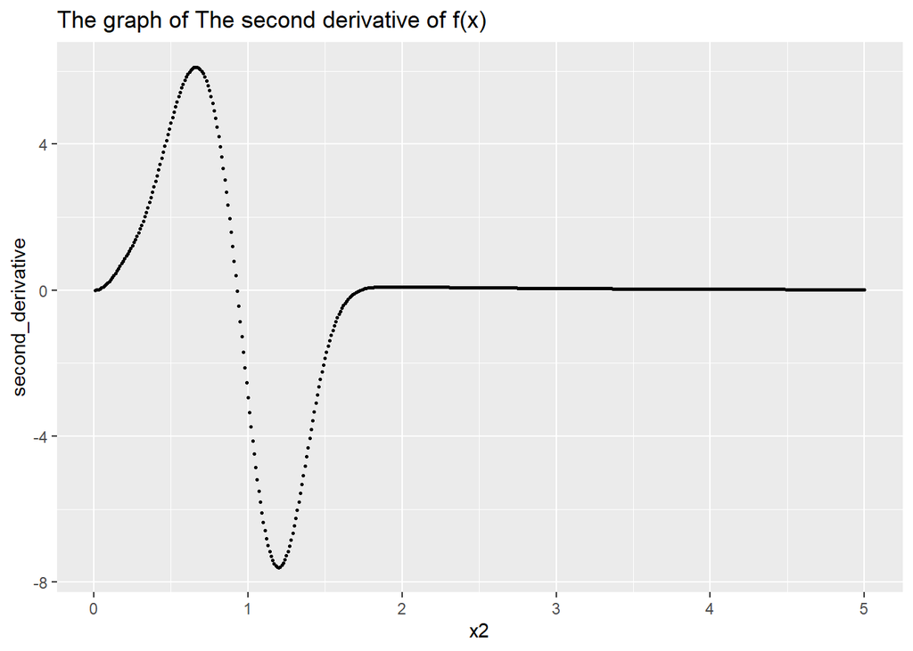

```r
x2 <- seq(0.01, 5, by=0.01)
dt <- tibble("x"=x2, "second_derivative"=f2(x2))
ggplot(dt, aes(x2, second_derivative)) +
        geom_point(size=0.5) +
        ggtitle("The graph of The second derivative of f(x)")
```

```r
# The second derivative of near x=5
tail(dt)
```

```
## # A tibble: 6 x 2
##       x second_derivative
##   <dbl>             <dbl>
## 1  4.95            0.0176
## 2  4.96            0.0175
## 3  4.97            0.0174
## 4  4.98            0.0173
## 5  4.99            0.0172
## 6  5               0.0172
```

```r
# The second derivative is positive at the large x.
f2(100)
```

```
## [1] 3.881587e-06
```

- Conclustion: From the result, NR method is sensitive to the choice of starting value. It could diverge or even obtain different points. From the graph, the second derivative approaches zero but positive. Thus, as x increases, the first derivative is positive and f(x) keeps increasing.

# Question 3: Multivariate optimization - Zero-inflated Poisson

Frequency Table

| 0 | 1 | 2 | 3 | 4 | 5 | 6 |
| --- | --- | --- | --- | --- | --- | --- |
| 3062 | 587 | 284 | 103 | 33 | 4 | 2 |

Loglikelihood function

$$\mathcal{l}(\boldsymbol{\theta}) = n_0\log(\pi + (1-\pi)e^{-\lambda}) + (N-n_0)[\log(1-\pi) - \lambda] + \sum_{i=1}^{\infty}in_i\log(\lambda)$$

fit this model with Newton-Raphson.

```r
# f(x)
logLik = function(theta, y, ny){
        pi <- theta[1]
        lam <- theta[2]

        value <- ny[1]*log(pi +(1-pi)*exp(-lam)) + (sum(ny)-ny[1])*(log(1-pi)-lam) + sum(y*ny) * log(lam)

        return(value)
}

# first derivative
f1 = function(theta, y, ny){
        pi <- theta[1]
        lam <- theta[2]

        drv_pi <- ny[1]*(1-exp(-lam))/(pi + (1-pi)*exp(-lam)) - (sum(ny)-ny[1])/(1-pi)

        drv_lambda <- -ny[1]*(1-pi)*exp(-lam)/(pi + (1-pi)*exp(-lam)) - (sum(ny)-ny[1]) + sum(y*ny)/lam

        return(matrix(c(drv_pi, drv_lambda), nrow=2))
}

# second derivative
f2 = function(theta,y, ny){
        pi <- theta[1]
        lam <- theta[2]

        sec_drv_pi <- -ny[1]*(1-exp(-lam))^2/(pi + (1-pi)*exp(-lam))^2 - (sum(ny)-ny[1])/(1-pi)^2

        sec_drv_lambda <- -ny[1]*(1-pi)^2*exp(-2*lam)/(pi + (1-pi)*exp(-lam))^2 +
                                ny[1]*(1-pi)*exp(-lam)/(pi + (1-pi)*exp(-lam)) - sum(y*ny)/lam^2

        sec_drv_pi_lambda <- ny[1]*(1-exp(-lam))*(1-pi)*exp(-lam)/(pi + (1-pi)*exp(-lam))^2 +
                                ny[1]*exp(-lam)/(pi + (1-pi)*exp(-lam))

        return(matrix(c(sec_drv_pi, sec_drv_pi_lambda, sec_drv_pi_lambda, sec_drv_lambda), nrow=2, byrow=TRUE))
}

# Iteration function
nr3 <- function(theta, y, ny, eps=Inf, tol=10^-4, iter=0, maxit=50) {
        init <- theta

        while (eps > tol & iter < maxit) {
                # Save the previous value
                theta0 <- theta

                # Calculate increment
                h <- -solve(f2(theta, y, ny)) %*% f1(theta, y, ny)

                # Update theta
                theta <- theta + h

                # Update f(x)
                value <- logLik(theta, y, ny)

                # Calculate diff between x
                eps <- sqrt(sum((theta - theta0) ^ 2))

                # Update iteration
                iter <- iter + 1
                if (iter == maxit) {
                        warning("Iteration limit reached without convergence")
                }
        }

        paste("The initial theta is (", round(init[1],digits=6), round(init[2],digits=6),
              "). The results of NR method are theta = (",
              round(theta[1], digits = 6), round(theta[2], digits = 6),
              ") and logLik =", round(value[1], digits = 6))
}
```

```r
# data
y = 0:6
ny = c(3062, 587, 284, 103, 33, 4, 2)
theta = c(
          ny[y==0]/sum(ny), # initial value for pi, prop of total 0's
          sum(ny*y)/sum(ny) # intial value for lambda, mean of y's
          )

# Results
nr3(theta, y, ny)
```

```
## [1] "The initial theta is ( 0.751411 0.399509 ). The results of NR method are theta = ( 0.615057 1.037839 ) and logLik = -2833.06275"
```

Given the estimates, interpret the results.

- Conclusion: The proportion of subjects who didn’t intended to go fishing is estimated 0.615057. On average, those who intended to go fishing caught 1.037839 fish.